# Bond Amortisation - R Example

### Initial Data

The data frame contains sample holdings data for 20 bonds. Lets assume all the bonds pays coupon semi-annually and accrual basis is ACT/365.

Bond Holdings as at 30-Sep-2009

[output not shown]

### Calculate Using Excel’s FV, PV and PRICE Functions

FV and PV methods produce the same results since they share some common variables and assumptions, such as assuming daily cash flow throughout the amortisation period. Price method is based on the YIELD and PRICE functions and follow day count conventions and hence, more reflective of actual cash flow.

YIELD Function

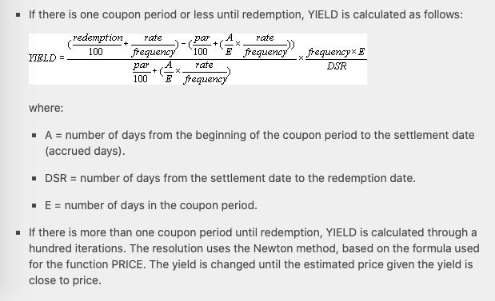

**Comparing Amortised Book Values of Bonds**  
Observe that the differences are relatively small between Price Method and the PV/FV methods.

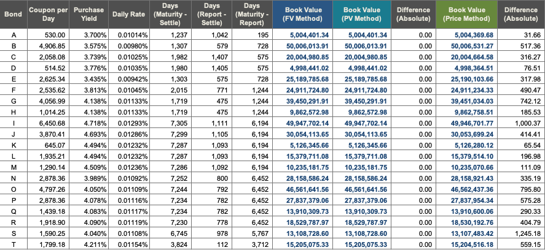

### Assign Variables and Create Columns

Now, we will show how to create a simple bond amortisation report using R. I will try to replicate the PV method used in Excel as the formula is quite straight-forward (not creating FV method here). The Price/Yield method in R, is expected to produce larger discrepancies. This is probably because the **BondValuation** package, although using the same Newton method, dives deeper into the bond’s cash flow characteristics. For example, different variants of ACT/365 day count convention can make a large difference in the yield. It is likely that your investment system’s algorithm are more closely designed this way.

You don’t have to write an entire program just to make comparisons if Excel does its job, although it helps to access data directly from database using SQL and make use of programs like R in which you can clean the data from before performing any analysis. Study what you are comparing against, what your tolerance level is and whether you want to monitor to ensure no unusual gaps.

Given the information in the top table table, we create a few new variables.

**Bond holdings information you need to compute everything else**

| No | Name | Description |
| --- | --- | --- |
| 1 | ParValue | Face or redemption value |
| 2 | Principal | Purchased amount (clean price) |
| 3 | SettleDate | Settlement date of purchase |
| 4 | MaturityDate | Maturity date of bond |
| 6 | CouponRate | Annual coupon rate |

**Create new variables**

[output not shown]

*Click the button on the right to display the code.*

```r
library(dplyr)
library(BondValuation)

ReportDate <- as.Date('2009-09-30')

AmortDays <- as.numeric(with(Holdings,as.Date(MaturityDate)-as.Date(SettleDate)))
DaysToMat <- as.numeric(with(Holdings,as.Date(MaturityDate)-as.Date(ReportDate)))
CouponDaily <- with(Holdings,ParValue*CouponRate/365)
```

Next, we establish the book value amount using PV method. The steps are:

1. find the yield per day (r) given the par value (P), purchase amount (S), daily coupon amount (C) and number of days from settlement to maturity (n). We use the standard PV formula (see *Deriving Financial Formulas using Geometric Series*):  
   $S =~ _C\frac{1-(1+r)^{-n}}{r} + \frac{P}{(1+r)^n}$  
   To avoid using the approximation formula, we use the optimisation technique where the absolute margin of error from the target number (in this case, S) is calculated for different r values. So we want to minimise the error to 0. We can use differentiation and weights to perform this (similar to back propagation in neural networks) but fortunately R comes with the optimize() function. This function calculates the r value where the gradient of the graph is 0.
2. Use the result of r and re-apply to the PV formula above but using this time, the number of days from reporting date to maturity date, to give you the book value.

```r
yield_error <- function(r,n,P,S,C) abs((C*(1-(1/(1+r)^n))/r + (P/(1+r)^n))-S)

YieldDaily <- vector("numeric",20) # an empty vector is required for the following loop to populate to.

for(i in 1:20){
  YieldDaily[i] = optimize(yield_error,
                           c(0,0.01),
                           P = Holdings$ParValue[i],
                           S = Holdings$Principal[i],
                           C = Holdings$ParValue[i]*Holdings$CouponRate[i]/365,
                           n = AmortDays[i],
                           tol = .Machine$double.xmin)[[1]]
# double square brackets to hide header for each record since the output is a list. Not necessary here but just to take note.
}

BookValue1 <- CouponDaily*(1-(1/(1+YieldDaily)^DaysToMat))/YieldDaily + (Holdings$ParValue/(1+YieldDaily)^DaysToMat)
```

The second method requires the package “BondValuation” to be installed. We use the package’s Yield function to calculate the book yield. Instead of supplying the number of days, we input the actual dates and let the function do the maths.

The resulting yield is then used to compute the price (package’s Price function) and finally the book value as at report date.

```r
BookYield <- vector("numeric",20)

for(i in 1:20){
  BookYield[i] = BondVal.Yield(CP = Holdings$Principal[i]/Holdings$ParValue[i]*100,
                             SETT = as.Date(Holdings$SettleDate[i]),
                             Mat = as.Date(Holdings$MaturityDate[i]),
                             CpY = 2,
                             Coup = Holdings$CouponRate[i]*100,
                             Em = as.Date('2000-01-01'), # arbitrary value, required field but not necessary for YTM calculation.
                             DCC=10,
                             Precision = .Machine$double.eps^0.75)[[4]] # cannot use xmin or lower as processing time will be too long.
}

PriceRD <- vector("numeric",20)

for(i in 1:20){
  PriceRD[i] = BondVal.Price(YtM = BookYield[i],
                             SETT = ReportDate,
                             Mat = as.Date(Holdings$MaturityDate[i]),
                             CpY = 2,
                             Coup = Holdings$CouponRate[i]*100,
                             Em = as.Date('2000-01-01'),
                             DCC = 10)[[1]]
}

BookValue2 <- PriceRD*Holdings$ParValue/100
DiffBV <- BookValue2-BookValue1
```

Create a new data frame to add all the variables as columns.

```r
amortisation <- Holdings %>%
  mutate(ReportDate,
         AmortDays,
         DaysToMat,
         CouponDaily,
         YieldDaily=YieldDaily*100,
         BookYield,
         PriceRD,
         BookValue1,
         BookValue2,
         DiffBV)%>%
  select(!c(ReportDate,CouponRate,MaturityDate,SettleDate,PriceRD))
```

Design the table output using DT.

```r
datatable(amortisation, rownames = FALSE, options = list(
 searching = FALSE,
 pageLength = 30,
 lengthMenu = c(10,20,30))) %>%
  formatRound(c('ParValue', 'Principal'), 0) %>%
  formatRound(c('BookValue1', 'BookValue2', 'DiffBV'),2) %>%
  formatRound(c('CouponDaily', 'BookYield', 'YieldDaily'),4) %>%
  formatRound('YieldDaily',6)
```

| Bond | ParValue | Principal | AmortDays | DaysToMat | CouponDaily | YieldDaily | BookYield | BookValue1 | BookValue2 | DiffBV |
| --- | --- | --- | --- | --- | --- | --- | --- | --- | --- | --- |
| A | 5000000 | 5026500 | 1237 | 195 | 530 | 0.010144078555699 | 3.70209941625768 | 5004401.33603032 | 5004084.80059675 | -316.53543356806 |
| B | 50000000 | 50010500 | 1307 | 728 | 4906.84931506849 | 0.00979657998542706 | 3.57896282369374 | 50006013.8907041 | 50002643.2078642 | -3370.68283993006 |
| C | 20000000 | 20016000 | 1982 | 575 | 2058.08219178082 | 0.0102458087221478 | 3.74027212867523 | 20004980.8424223 | 20003485.9288696 | -1494.91355272382 |
| D | 5000000 | 4995000 | 1980 | 575 | 514.520547945205 | 0.0103462682850443 | 3.77723856899577 | 4998441.0150832 | 4998066.80255974 | -374.212523462251 |
| E | 25000000 | 25330750 | 1303 | 728 | 2625.34246575343 | 0.009422368911451 | 3.43924670485851 | 25189785.6664651 | 25188061.9165439 | -1723.74992115051 |
| F | 25000000 | 24862500 | 2015 | 1244 | 2535.61643835616 | 0.0104451638028964 | 3.81992901199433 | 24911724.820357 | 24911158.7822379 | -566.038119155914 |
| G | 40000000 | 39260000 | 1719 | 1244 | 4056.98630136986 | 0.0113269054727421 | 4.14263827449015 | 39450291.8791314 | 39452875.69464 | 2583.8155085966 |
| H | 10000000 | 9815000 | 1719 | 1244 | 1014.24657534247 | 0.0113269054727421 | 4.14263827449015 | 9862572.96978285 | 9863218.92366 | 645.95387714915 |
| I | 50000000 | 49942000 | 7305 | 6194 | 6450.68493150685 | 0.0129259101854432 | 4.72091011100386 | 49947701.8303291 | 49945939.832227 | -1761.998102054 |
| J | 30000000 | 30060000 | 7299 | 6194 | 3870.41095890411 | 0.0128591253877254 | 4.69633391176738 | 30054113.7222836 | 30053059.6300135 | -1054.09227010235 |

[output cut: 10 more lines]